# Week 6: Overfitting and cross-validationv20260309c

**Content:**

- Part 1: Understanding over-fitting
- Part 2: Estimating the Generalization Error through Cross-Validation.
- Part 3: Cross-Validation for Model Selection (KNN example)
- Part 4: Decision tress and cross-Validation for Model Selection
- Assignment 6: Two-layer cross-validation

**Objectives:**

- Understand under- and overfitting.
- Understand the difference between training, test and generalization error.
- Explain how cross-validation can be used for (i) performance evaluation and (ii) model selection.
- Implement and apply model selection and perforamnce evaluation using two-layer cross validation

```python
import numpy as np
import pandas as pd
import seaborn as sns
import matplotlib.pyplot as plt
import random

from sklearn.preprocessing import PolynomialFeatures
from sklearn.linear_model import LinearRegression
from sklearn.pipeline import make_pipeline
from sklearn.metrics import mean_squared_error
import matplotlib.gridspec as gridspec
# from sklearn.model_selection import train_test_split, KFold, LeaveOneOut
from sklearn.neighbors import KNeighborsClassifier

# Plotting style
sns.set_style('darkgrid')
sns.set_theme(font_scale=1.)

import utils as utils, re # contains some handly plotting functions

# Random seed
seed = 123
np.random.seed(seed)
random.seed(seed)
```

## Introduction

There are many ways to fit a model to data and achieve low training error, but this alone does not guarantee good performance on new, unseen data. A model that is too simple to capture the underlying structure, while one that is too complex may memorize noise rather than learn the underlying signal. In both cases, the result is poor generalization.

Our goal is not just to explain the training data, but to build models that generalize - performing well on data they have never encountered.

The central theme is the trade-off between model complexity and generalization ability. Too simple, and the model underfits; too complex, and it overfits.  
We will look at practical ways to approximate generalization error, optimize modeling choices, and reduce overfitting.

## Part 1: Understanding over-fitting (and revisiting the linear model)

In this exercise, we will be demonstrating under- and overfitting in context of the linear models we exmained last week on a simple 3rd degree polynomial, $y = 10x^3 - 5x$, plotted in the following cell.

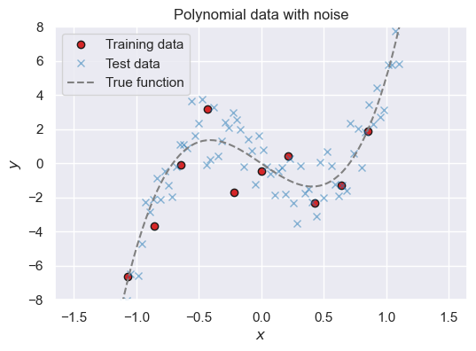

```python
# Set random seed for reproducibility
np.random.seed(seed)

# Define data-generating function
func = lambda x: 10 * x**3 - 5 * x

# Optional: you can try with a different function and see how it changes the result
#func = lambda x: 2.5*np.sin(2.1*x) + 2.5*x
#func = lambda x: 4 * x**3 - 5 * x
#func = lambda x: 1.5 * x**3 - x

sigma = 1.1

# Generate training data from a polynomial
N_train = 15
X_train = np.linspace(-1.5, 1.5, N_train).reshape(-1,1) # Training inputs
y_train = func(X_train) + sigma*np.random.randn(N_train).reshape(-1,1) # Training outputs with noise

# Generate test data from a polynomial
N_test = 100
X_test = np.linspace(-1.5, 1.5, N_test).reshape(-1,1) # Test inputs
y_test = func(X_test) + sigma*np.random.randn(N_test).reshape(-1,1) # Test outputs with noise

# Combine train and test data for later use.
X = np.vstack((X_train, X_test))
y = np.vstack((y_train, y_test))

# Plot the data using the function
fig, ax = plt.subplots(figsize=(6, 4))
utils.plot_polynomial_data(X_train, y_train, X_test, y_test=y_test, func=func, ax=ax)
ax.set_title("Polynomial data with noise")
ax.legend()

assert(X_train.shape == (N_train,1)) # we just check the sizes to avoid issues later
assert(y_train.shape == (N_train,1))
```

Last week we saw that the parameters of a linear regression model can be found by minimizing the least-squares error. In matrix form, this gives a closed-form solution for the weights.

$$ \boldsymbol{w}^\ast = \left(\tilde{\boldsymbol{X}}^\top \tilde{\boldsymbol{X}}\right)^{-1} \tilde{\boldsymbol{X}}^\top \boldsymbol{y} $$

Alternatively, we can rewrite this as a system of linear equations, which is often more numerically stable to solve using `np.linalg.solve`, since this avoids explicitly inverting a matrix.

$$ \left(\tilde{\boldsymbol{X}}^\top \tilde{\boldsymbol{X}}\right)\boldsymbol{w}^\ast = \tilde{\boldsymbol{X}}^\top \boldsymbol{y} $$

> *Alternative:* Instead of computing this directly, we can rely on `sklearn.linear_model.LinearRegression()` to estimate the model.

If we want to extend linear regression to handle polynomials, for example to fit curves instead of just straight lines, we can do this by expanding our input features into polynomial terms. For a single input variable $x$ and a polynomial of degree $k$, we transform each input into

$$ \phi(x) = \begin{bmatrix} 1 \\ x \\ x^2 \\ \vdots \\ x^k \end{bmatrix}, $$ so that the model becomes $\hat{y} = w_0 + w_1 x + w_2 x^2 + \cdots + w_k x^k.$. In matrix form, the design matrix is therefore expanded to

$$ \tilde{\boldsymbol{X}} = \begin{bmatrix} 1 & x_1 & x_1^2 & \cdots & x_1^k \\ 1 & x_2 & x_2^2 & \cdots & x_2^k \\ \vdots & \vdots & \vdots & \ddots & \vdots \\ 1 & x_N & x_N^2 & \cdots & x_N^k \end{bmatrix}. $$

We can then solve for the polynomial regression weights in exactly the same way as for ordinary linear regression, but using this expanded feature matrix.

> *Alternative:* In scikit-learn, this expansion can be done using `sklearn.preprocessing.PolynomialFeatures(degree)`, but we want you to understand the basic idea before relying on toolbox functions that hide the details.

**Task 1.1:** Fit polynomial regression models with different degrees to the data. Plot the resulting curves together with the observed data, and describe how increasing the polynomial degree affects the fit.

```python
def create_polynomial_features(X, degree):
    ### BEGIN SOLUTION
    X_tilde = np.hstack([X**p for p in range(degree + 1)])
    ### END SOLUTION
    return X_tilde

# Set the degree of the polynomial and create the X_tilde for testing that it looks correct
degree = 3 # degree of the polynomial
X_tilde = create_polynomial_features(X_train, degree)
print(f"X_tilde=\n{np.array2string(X_tilde, precision=2)}")

# Small unit test to check the size of the augmented data matrix
assert(X_tilde.shape == (N_train, degree + 1))
```

```
X_tilde=
[[ 1.   -1.5   2.25 -3.38]
 [ 1.   -1.29  1.65 -2.13]
 [ 1.   -1.07  1.15 -1.23]
 [ 1.   -0.86  0.73 -0.63]
 [ 1.   -0.64  0.41 -0.27]
 [ 1.   -0.43  0.18 -0.08]
 [ 1.   -0.21  0.05 -0.01]
 [ 1.    0.    0.    0.  ]
 [ 1.    0.21  0.05  0.01]
 [ 1.    0.43  0.18  0.08]
 [ 1.    0.64  0.41  0.27]
 [ 1.    0.86  0.73  0.63]
 [ 1.    1.07  1.15  1.23]
 [ 1.    1.29  1.65  2.13]
 [ 1.    1.5   2.25  3.38]]
```

**Task 1.2** Complete the function that solves the least squares problem and run it to fit the parameters to the `X_train` and `y_train`

> *Hint* Consider how many elements `w_star` must contain before writing/running the code.

> *Hint*: We did this last week as well

```python
# The function solves the least squares problem for arbitray X and y to find the optimal weights in a polynomial regression model
def fit_pm(X, y, degree):
    X_tilde = create_polynomial_features(X, degree)
    ### BEGIN SOLUTION
    w_star = np.linalg.solve(X_tilde.T @ X_tilde, X_tilde.T @ y)  # Shape: (degree+1, 1)
    ### END SOLUTION
    return w_star

# Fit the model using the function
w_star = fit_pm(X_train, y_train, degree)
print(f"Learned weights\nw_star=\n{np.array2string(w_star, precision=3)}")

# Just check that the shape is correct
assert(fit_pm(X_train, y_train, degree).shape == (degree + 1, 1)) # check the size of the weights
```

```
Learned weights
w_star=
[[-0.247]
 [-4.708]
 [ 0.026]
 [ 9.866]]
```

**Task 1.3** Complete the function `predict_pm`, which uses the learned weights to predict the output for a given input `X` (the degree is given explicitly to make sure that the same polynomial basis is used as during training). We use `create_polynomial_features` to construct the polynomial basis from the input `X`. Given an input matrix expanded into polynomial features, predictions are computed as $ \hat{\boldsymbol{y}} = \tilde{\boldsymbol{X}} \boldsymbol{w}^\ast. $ The function first calls `create_polynomial_features(X, degree)`. You should then multiply the resulting data matrix by the learned weight vector to return the predicted outputs in the variable `y_pred`.

```python
# Create a predict function using the create_polynomial_features function from above
def predict_pm(w_star, X, degree):
    # First create the augmented data matrix for the test points
    X_tilde = create_polynomial_features(X, degree)  # Shape: (N_test, degree + 1)

    # 1.3) Compute y_pred
    ### BEGIN SOLUTION
    y_pred = X_tilde @ w_star  # Shape: (N_test, 1)
    ### END SOLUTION

    return y_pred

# Predict the outputs for the test data to inspect what the model predicts
y_pred = predict_pm(w_star, X_test, degree)
#print(f"Predicted outputs\ny_pred=\n {np.array2string(y_pred.flatten(), precision=2)}")
```

**Task 1.4** We run all the steps in one cell for convinience and plot the results

Overall steps:

- Set degree of the polynomial,
- Fit model to get w_star
- Predict the outputs for the test data.

> *Note* We postfix the variables with `_visu` to avoid confusing them with the ones above in case you need to revisit the function to make it work.

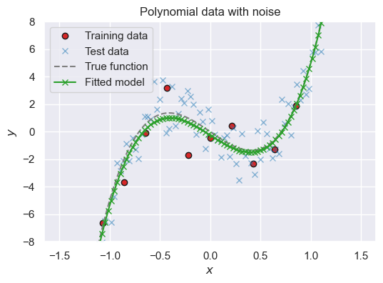

```python
degree_visu = 3 # degree of the polynomial
w_star_visu = fit_pm(X_train, y_train, degree_visu)
y_pred_visu = predict_pm(w_star_visu, X_test, degree_visu)

# Plot the data
fig, ax = plt.subplots(figsize=(6, 4))
utils.plot_polynomial_data_with_pred(X_train, y_train, X_test, y_test=y_test, func=func, y_pred=y_pred_visu, ax=ax)
ax.legend()
ax.set_title("Polynomial data with noise")
```

**Task 1.5:** Experiment with different polynomial degrees in `degree_visu`. Can you make the model so simple that it simply fits a slope - or even a constant?

> *Hint:* Make the model simpler by decreasing the degree (e.g. set `degree_visu=0`).

> *Hint:* This is what's known as underfitting.

**Task 1.6:** Can you make the model so complex that it fits the training data exactly (matching every point)? Reflect on how the model performns on the test points.

> *Hint:* Make the model more complex by increasing the degree (e.g. set `degree_visu` to the number of training points...).

> *Hint:* This is what's known as overfitting.

We’ll now examine how the training and test errors change as we vary the polynomial degree, moving from underfitting to overfitting.

**Task 1.7:** To evaluate the model, we first compute predictions on the training and test sets: $$ \hat{\boldsymbol{y}}_{\mathrm{train}} = \tilde{\boldsymbol{X}}_{\mathrm{train}} \boldsymbol{w}^\ast, \qquad \hat{\boldsymbol{y}}_{\mathrm{test}} = \tilde{\boldsymbol{X}}_{\mathrm{test}} \boldsymbol{w}^\ast. $$ The error for each example is the difference between the true target value and the predicted value. To summarize these errors, we use the root mean squared error (RMSE), defined as $$ \mathrm{RMSE} = \sqrt{\frac{1}{N}\sum_{i=1}^n \left(y_i - \hat{y}_i\right)^2 }. $$ Your task is therefore to use the fitted model to predict the outputs for both the training and test inputs, compute these two quantities, and store them in `RMSE_train` and `RMSE_test`.

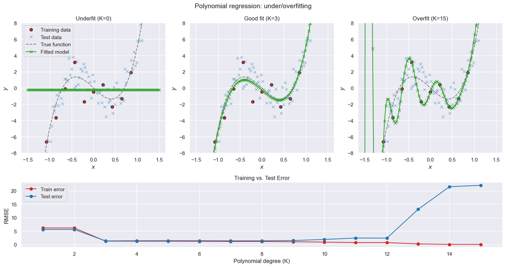

```python
# Setting up figure
fig = plt.figure(figsize=(15, 8))
fig.suptitle("Polynomial regression: under/overfitting", fontsize=14)
gs = gridspec.GridSpec(2, 3, height_ratios=[2, 1])
axes_top = [fig.add_subplot(gs[0, i]) for i in range(3)]
ax_bottom = fig.add_subplot(gs[1, :])  # span all 3 columns

# Degrees and titles for the three columns
degrees = [0, 3, 15]
titles = [f"Underfit (K={degrees[0]})",
          f"Good fit (K={degrees[1]})",
           f"Overfit (K={degrees[2]})"]

# Model fitting / prediction and plotting
for ax, degree_sweep, title in zip(axes_top, degrees, titles):
    w_star_sweep = fit_pm(X_train, y_train, degree_sweep)
    y_pred_sweep = predict_pm(w_star_sweep, X_test, degree_sweep)
    utils.plot_polynomial_data_with_pred(X_train, y_train, X_test, y_test=y_test, func=func, y_pred=y_pred_sweep, ax=ax)
    ax.set_title(title)
    axes_top[0].legend(loc="best")

# Fit and predict for K = 1..15
train_errors, test_errors = [], []
for degree_sweep in range(1, max(degrees) + 1):
    # Fit the model.
    w_star_sweep = fit_pm(X_train, y_train, degree_sweep)

    # Predict on training and test data,
    y_train_pred = predict_pm(w_star_sweep, X_train, degree_sweep)
    y_test_pred = predict_pm(w_star_sweep, X_test, degree_sweep)

    # 1.7) Calculate the root mean square error and save them as RMSE_train and RMSE_test.v Use only numpy
    ### BEGIN SOLUTION
    RMSE_train = np.sqrt(np.mean((y_train - y_train_pred) ** 2))
    RMSE_test = np.sqrt(np.mean((y_test - y_test_pred) ** 2))
    ### END SOLUTION

    # Store the errors
    train_errors.append(RMSE_train)
    test_errors.append(RMSE_test)

ax_bottom.plot(range(1, max(degrees) + 1), train_errors, "-o", color="tab:red", label="Train error")
ax_bottom.plot(range(1, max(degrees) + 1), test_errors, "-o", color="tab:blue", label="Test error")
ax_bottom.set_xlabel("Polynomial degree (K)")
ax_bottom.set_ylabel("RMSE")
ax_bottom.set_title("Training vs. Test Error")
ax_bottom.legend()
ax_bottom.grid(True)
plt.tight_layout()
```

This should serve as an example of **over-** and **underfitting**. A model that’s too simple can’t capture the training data well, while a model that’s too complex ends up relying too heavily on the training data and fails on new, unseen test data.  
In this case, you can see the model fitting the training points perfectly (if `degrees` has the last element set to the numbe rof training points), but that “perfection” actually hurts its ability to generalize.

The bottom plot shows this trade-off: the training error keeps going down as the model gets more complex, but at some point the test error starts to rise sharply.

So how do we stop a model from overfitting? One way is to simplify the model by reducing the number of weights, as we have just seen above.  
Another is to give it more training data, such that the model has a better chance to learn the real patterns, rather than the noise. In the coming weeks, we’ll also see how **regularization** can help address overfitting.

**Task 1.8:** Increase the number of training points in the above examples. What happens to the overfitted model when $N_{train}=50, 100, 1000$?

> *Hint*: Does the overfittign get less or more severe?

## Part 2: Estimating the Generalization Error using Cross-Validation

In the above example, you saw how the **test error** is a much better representation of the true performance of the model than the **training error**. As you might have noticed in the code-block, we used the *holdout*-method, where the data is split into a single *training-* and *testset*.  
In cases of small test-sets, this might lead to a crude approximation of the actual generalization error - as the data might be randomly be split into sets that don't represent the actual distribution well. We will therefore look at more comprehensive methods of estimating the **generalization error**, through **cross-validation**.

As you might recall from the lecture, the generalization error is the test error evaluated over an *_infinitely_* large (unseen) test set. In other words, it's the "true performance" of a model, if we were to test it on an infinite amount of new, unseen data.

Intuitively, this is simply not feasible in the real world, where data is often limited, and thus our only option is to **estimate** the generalization error instead.

Cross-validation is a method we use to estimate the generalization error, and it is particularly useful when we don't have a lot of data. We will look at three different methods:

1. **Holdout**: Partitions dataset in two (training, test), we approximate the generalization error based on the resulting test set.
2. **K-fold**: Partitions dataset $K$ times, such that all observations get to act as test-points in a single fold. We train the model $K$ times and approximate the generalization error by averaging over the $K$ test results.
3. **Leave-one-out**: Partitions dataset into as many folds as there are observations, such that each observation acts as a test point once. We train the model $N$ times (where $N$ is the number of samples) and approximate the generalization error by averaging over all $N$ test results.

Each of the three methods has its own advantages and drawbacks. In general, increasing the number of folds gives us a more reliable estimate of the generalization error, but it also requires training more models and therefore consumes more computational resources. With the holdout method, there is always the risk of an “unlucky” split, where the training and test sets do not represent the overall data distribution well, leading to an unreliable performance estimate.  
As a rule of thumb: the more data we have, the fewer folds we need.

In this exercise, we will compare three approaches to splitting the data: **holdout**, **K-fold**, and **leave-one-out**.  
For each method, we will once again fit a 3rd degree polynomial to the above data - and compare the results we find in each fold, as well as across methods.

**Task 2.0** This function splits the input data `X` and labels `y` into training and test sets. It first shuffles the sample indices randomly, then uses those indices to separate a portion of the data for testing and the rest for training. The function returns the training features, test features, training labels, and test labels. Complete the functin by using the shuffled index array `idx` to create two new arrays:

- `test_idx` should contain the first `N_test` indices.
- `train_idx` should contain all remaining indices.

This splits the shuffled data indices into a test set and a training set.

```python
def train_test_split_np(X,y, test_size=0.25, random_state=1):
    N = X.shape[0]
    idx = np.arange(N)
    rng = np.random.default_rng(random_state)
    rng.shuffle(idx) # shuffel the ordering of the data
    N_test = int(np.ceil(N * test_size))

    #Create the arrays with indencies for he the test set and tran set
    ### BEGIN SOLUTION
    test_idx = idx[:N_test]
    train_idx = idx[N_test:]
    ### END SOLUTION

    #print(train_idx)
    #print(test_idx)

    # Collect the outputs
    out = []
    out.extend([X[train_idx], X[test_idx]])
    out.extend([y[train_idx], y[test_idx]])
    return out
```

**Task 2.1:** Split $\boldsymbol{X}$ and $\boldsymbol{y}$ into a training and test split with the holdout method, using a 80/20 split. SAve the resulting subset in `X_train`, `X_test`, `y_train`, and `y_test`. Finally, we train a model on the train set and evaluate on the test set.

> *Hint:* Use the function `train_test_split()`.

> *Hint:* Remember to use `random_state = seed`.

```
X_train.shape: (92, 1)
X_test.shape: (23, 1)
y_train.shape: (92, 1)
y_test.shape: (23, 1)
```

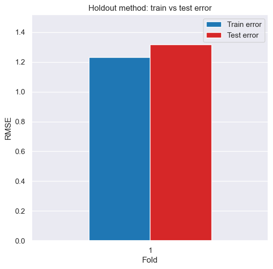

```python
# 2.1) Holdout Method (20% test size) - split X and y into X_train, X_test, y_train, y_test
### BEGIN SOLUTION
X_train, X_test, y_train, y_test = train_test_split_np(X, y, test_size=0.2, random_state=seed)
### END SOLUTION

# We check the sizes of the splits
print("X_train.shape:", X_train.shape)
print("X_test.shape:", X_test.shape)
print("y_train.shape:", y_train.shape)
print("y_test.shape:", y_test.shape)

# We now fit the models using the data splits
errors = {} # Dictionary to store errors for each method
degree = 3 # Use degree 2 for the rest of the exercise

# Initialize model
model = make_pipeline(PolynomialFeatures(degree), LinearRegression())
# Fit model
model.fit(X_train.reshape(-1, 1), y_train)
# Predict
y_train_pred = model.predict(X_train.reshape(-1, 1))
y_test_pred  = model.predict(X_test.reshape(-1, 1))

# Compute errors
train_error = np.sqrt(mean_squared_error(y_train, y_train_pred))
test_error  = np.sqrt(mean_squared_error(y_test, y_test_pred))

# Bar plot "holdout" train and test error
utils.plot_fold_errors(np.array([(train_error, test_error)]))
plt.title('Holdout method: train vs test error')

# Save mean errors for later comparison
errors['Holdout'] = (train_error, test_error)
```

**Task 2.2:** Inspect and run the function `kfold_np` so that it creates **K-fold cross-validation splits** from the shuffled sample indices. ,

```python
def kfold_np(n_samples, n_splits=5, random_state=1):
    idx = np.arange(n_samples)
    rng = np.random.default_rng(random_state)
    rng.shuffle(idx)

    fold_sizes = np.full(n_splits, n_samples // n_splits)
    fold_sizes[:n_samples % n_splits] += 1
    current = 0
    folds = []
    for fold_size in fold_sizes:
        test_idx = idx[current:current + fold_size]
        train_idx = np.concatenate((idx[:current], idx[current + fold_size:]))
        folds.append({"train_idx": train_idx,"test_idx": test_idx})
        current += fold_size
    return folds

fold_errors = []
K = 5
cv_folds = kfold_np(X.shape[0], n_splits=K, random_state=seed)

# We inspect the first fold, make sure there is no overlap between traning and test points (you could make a small test for this if you like)
cv_folds[0]
```

```
{'train_idx': array([ 81,  48,  72,  92,  14,   3,   0,  23,  39,  66,  56,   4,  21,
        112,  89,  65,  82,  52, 114,  71,  40,   2, 109,  96,  32,  11,
         47, 110,  74,  80, 100,  10,  34, 113,  54,  28,  18,  78,  13,
          7,   9, 107, 111,  64, 104,  51,  84,  20,  97,  26, 103,  90,
         93,  87,  68,  30,  19,  60, 101,  98,  42,  24, 102, 108,  99,
         59,  63,  29,  69,  27,  61,  45,  75,  62,   6,   8,  33,  44,
         88,  12,  16,  73,  76,  86,  49,   5,  46,  22,  91,  35,  25,
         77]),
 'test_idx': array([ 31,  53, 106,  57,  85,  17,  36,  55,  79,  67,  15,   1,  38,
         43,  70, 105,  83,  94,  58,  50,  41,  37,  95])}
```

**Task 2.3** Evaluate the performance of a polynomial regression model using **K-fold cross-validation**. Instead of using a single train/test split, cross-validation divides the dataset into multiple folds. The model is trained and tested several times, each time using a different fold as the test set and the remaining folds as the training set. This provides a more reliable estimate of model performance.

We have `cv_folds`, where each element contains the indices for the training and test sets of one fold. For each fold now:

1. Retrieve the training and test indices from the current fold (you should complete this part)
2. Use these indices to split `X` and `y` into: `X_train`, `X_test`, `y_train`, and `y_test` (you have to do this)
3. Train the polynomial model using the training data.
4. Compute predictions for both the training and test sets.
5. Calculate the **RMSE** for both sets and store the results (you should complte this part)

Finally, the errors from all folds are plotted and the **average training and test errors** across folds are stored for later comparison.

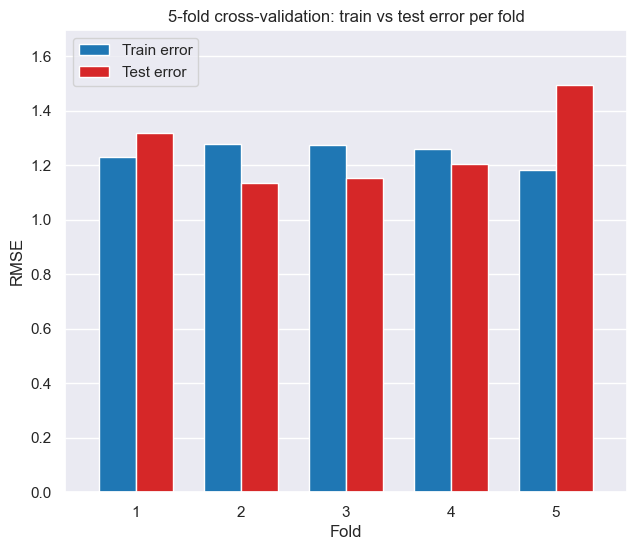

```python
degree = 3
fold_errors = []

# Loop through the folds
for fold_k, data_splits in enumerate(cv_folds):
    train_index = data_splits["train_idx"]
    test_index = data_splits["test_idx"]

    # 2.3) Split X and y into X_train, X_test, y_train and y_test according to the current fold.
    ### BEGIN SOLUTION
    X_train, X_test = X[train_index], X[test_index]
    y_train, y_test = y[train_index], y[test_index]
    ### END SOLUTION

    # Fit model.
    w_star = fit_pm(X_train, y_train, degree)

    # Predict
    y_train_pred = predict_pm(w_star, X_train, degree)
    y_test_pred  = predict_pm(w_star, X_test, degree)

    # Compute RMSE for both test and training sets
    train_error = np.sqrt(mean_squared_error(y_train, y_train_pred))
    test_error  = np.sqrt(mean_squared_error(y_test, y_test_pred))

    fold_errors.append((train_error, test_error))

# Bar plots for each fold train and test error
fold_errors = np.array(fold_errors)
utils.plot_fold_errors(fold_errors)
plt.title('5-fold cross-validation: train vs test error per fold')

# Save mean errors for later comparison
errors['5-Fold CV'] = (np.mean(fold_errors[:, 0]), np.mean(fold_errors[:, 1]))
```

**Task 2.4:** Now do a leave-one-out experiment. Split $\boldsymbol{X}$ and $\boldsymbol{y}$ into a training and test split with the test set only contaning one obseravtion.

> *Hint*: You only have to set `K_loo`to the value resulting in a LOO procedure

> *Hint:* Index `X` and `y` by the indexes provided in the for-loop.

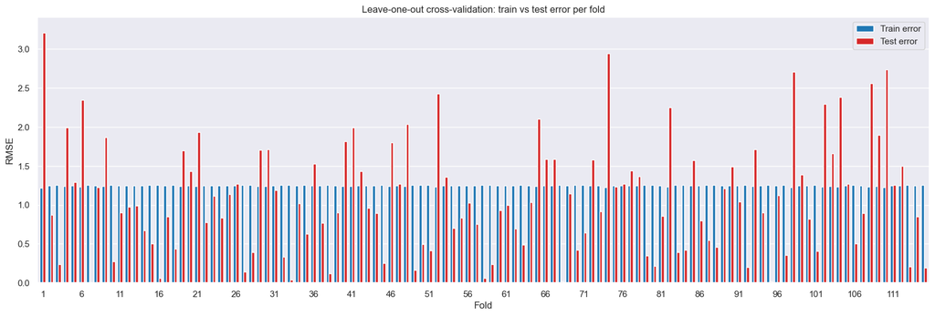

```python
# Empty list to store errors for each fold
fold_errors = []

# 2.4) Leave-one-out cross-validation
### BEGIN SOLUTION
K_loo = X.shape[0]
### END SOLUTION
cv_folds = kfold_np(X.shape[0], n_splits=K_loo, random_state=seed)

# Loop through the folds
for fold_k, data_splits in enumerate(cv_folds):
    train_index = data_splits["train_idx"]
    test_index = data_splits["test_idx"]

    # Split X and y into X_train, X_test, y_train and y_test according to the current fold.
    X_train, X_test = X[train_index], X[test_index]
    y_train, y_test = y[train_index], y[test_index]

    # Initialize and fit model.
    w_star = fit_pm(X_train, y_train, degree)

    # Predict
    y_train_pred = predict_pm(w_star, X_train, degree)
    y_test_pred  = predict_pm(w_star, X_test, degree)

    # Compute errors
    train_error = np.sqrt(mean_squared_error(y_train, y_train_pred))
    test_error  = np.sqrt(mean_squared_error(y_test, y_test_pred))

    # Store the errors for this fold
    fold_errors.append((train_error, test_error))

# Bar plots for each fold train and test error
fold_errors = np.array(fold_errors)
utils.plot_fold_errors(fold_errors)
plt.title('Leave-one-out cross-validation: train vs test error per fold')

# Save mean errors for later comparison
errors['LeaveOneOut CV'] = (np.mean(fold_errors[:, 0]), np.mean(fold_errors[:, 1]))
```

**Task 2.5:** How come the test results vary so much from fold to fold in the cases of K-fold and leave-one-out? Relate it to the single fold of holdout, and why these methods are better at estimating the Generalization Error.

- *Answer:*

We now plot the estimates obtained using the three different approaches side by side

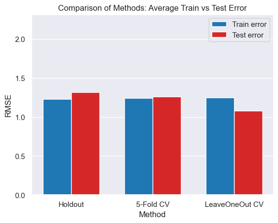

```python
# Bar plot of all methods
f = plt.figure()
plt.title('Comparison of Methods: Average Train vs Test Error')
bar_width = 0.35
index = np.arange(len(errors))
train_errs = [v[0] for v in errors.values()]
test_errs  = [v[1] for v in errors.values()]
plt.bar(index, train_errs, bar_width, color='tab:blue', label='Train error')
plt.bar(index + bar_width, test_errs, bar_width, color='tab:red', label='Test error')
plt.xlabel('Method')
plt.ylabel('RMSE')
plt.xticks(index + bar_width / 2, [k for k in errors.keys()])
plt.ylim(0, max(train_errs + test_errs) + 1)
plt.legend()
plt.grid(axis='x')
```

**Task 2.6:** Which is a more accurate estimation of the Generalization Error?

> *Hint*: This is a very tricky question and depends on the context - talk to your TA about it! We will also consider it more formally next week.
- *Answer:*

**Task 2.7:** Why does leave-one-out cross-validation produce a lower test error than 5-fold cross-validation?

> *Hint* Think about how many data points were used when training the models within each fold.
- *Answer:*

## Part 3: Cross-Validation for Model Selection

**Task 3.1:** Load the Iris dataset into $\boldsymbol{X}$ and $\boldsymbol{y}$.

> *Hint:* Remember to make $\boldsymbol{y}$ categorical.

```python
### BEGIN SOLUTION
# Load the iris dataset
df = pd.read_csv("data/iris.csv")

# Split the data frame into features and labels
X = df.drop(columns=["Type"])
y = pd.Categorical(df["Type"])
### END SOLUTION

assert X.shape == (150, 4), "There should be 150 samples and 4 features in the Iris dataset."
assert y.shape == (150,), "There should be 150 labels in the Iris dataset."
```

**Task 3.2:** Complete the leave-one-out cross-validation (for model selection) implementation in the code below (after Task 3.4). Define the variable `K_loo`controlling the number of folds

> *Hint:* Use LOO for the cross-validation.

**Task 3.3:** Split $\boldsymbol{X}$ and $\boldsymbol{y}$ according to the current fold in the for-loop.

> *Hint:* You might have to use `.iloc` as we're using Pandas for our data.

**Task 3.4:** For each fold, loop over the different values of $k$. For each $k$, define a KNN model with $k$ neighbors, fit it, make predictions, and compute the classification error. Store the test error in `errors_test[fold, k - 1]` and teh training error in `errors_train[fold_i, k - 1]`

> *Hint:* For convenience, we use KNeighborsClassifier from sklearn.neighbors so that we do not have to implement it ourselves this week. However, ambitious students are encouraged to try implementing their own version.

> *Hint* This can take a minute or two (think abut how many models we need to fit in total)

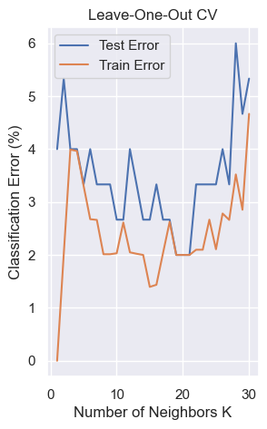

```python
K_neighbours = 30 # Max neighbors
errors_test = np.zeros((len(X), K_neighbours))
errors_train = np.zeros((len(X), K_neighbours))

# 3.2) Ensure we do leave-one-out cross-validation. Define K_loo
### BEGIN SOLUTION
K_loo = len(X)  # Number of folds for leave-one-out CV
### END SOLUTION

cv_folds = kfold_np(X.shape[0], n_splits=K_loo, random_state=seed)

# Loop through the folds
for fold_i, data_splits in enumerate(cv_folds):
    train_index = data_splits["train_idx"]
    test_index = data_splits["test_idx"]

    # 3.3) Split X and y according to the current fold, name them X_train, X_test, y_train, y_test.
    ### BEGIN SOLUTION
    X_train, X_test = X.iloc[train_index], X.iloc[test_index]
    y_train, y_test = y[train_index], y[test_index]
    ### END SOLUTION

    for k in range(1, K_neighbours + 1):
        # 3.4) For each $k$, define a KNN model with $k$ neighbors, fit it, make predictions.
        knn = KNeighborsClassifier(n_neighbors=k)
        knn.fit(X_train, y_train)
        y_est_test = knn.predict(X_test)
        y_est_train = knn.predict(X_train)

        # 3.4) Compute classification error for this fold
        ### BEGIN SOLUTION
        errors_test[fold_i, k - 1] = np.mean(y_est_test != y_test)
        errors_train[fold_i, k - 1] = np.mean(y_est_train != y_train)
        ### END SOLUTION

# Plot mean errors for each K
mean_errors_test = np.mean(errors_test, axis=0)
mean_errors_train = np.mean(errors_train, axis=0)

f = plt.figure(figsize=(3,5))
plt.title('Leave-One-Out CV')
plt.xlabel('Number of Neighbors K')
plt.ylabel('Classification Error (%)')
plt.plot(range(1, K_neighbours + 1), mean_errors_test * 100)
plt.plot(range(1, K_neighbours + 1), mean_errors_train * 100)
plt.legend(['Test Error', 'Train Error'])
plt.grid(True)
```

**Task 3.5:** Argue the number of neighbours that would be best for our KNN model on the Iris data.

- *Answer:*

**Task 3.6:** Try exchanging the LOO for Holdout and 10-fold CV and time the run-time. What's the time difference, and how come?

> *Hint:* You might not even have to change the code, can you think of a way to calculate an estimation of the time difference?

## Part 4: Decision trees on the Iris dataset

In this part, we will work with a **decision tree classifier** on the classic Iris dataset. Rather than implementing the algorithm from scratch, we will use `DecisionTreeClassifier` from `sklearn.tree`. Implementing a decision tree manually can be quite tedious, so using scikit-learn lets us focus on understanding how the model works and how to evaluate its performance. It also gives us a chance to see how scikit-learn can be used to train models and extract useful evaluation metrics.

**Task 4.1:** Run the code to (re)load the Iris dataset into $\mathbf{X}$ and $\mathbf{y}$. No coding is required for this task - just run it.

```python
# Load the iris dataset
df = pd.read_csv("data/iris.csv")

# Split the data frame into features and labels
X = df.drop(columns=["Type"])
y = pd.Categorical(df["Type"])

assert X.shape == (150, 4), "There should be 150 samples and 4 features in the Iris dataset."
assert y.shape == (150,), "There should be 150 labels in the Iris dataset."
```

**Task 4.2:** Train the decision tree on the training data, then use the fitted model's `clf.predict` to predict the labels for both `X_test` and `X_train`. Store the predictions in `y_pred_test` and `y_pred_train`, and use them to compare test and training accuracy.

```
Accuracy (Test): 0.9666666666666667
Accuracy (Train): 1.0
Max depth of the tree: 15
Actual depth of the tree: 5
```

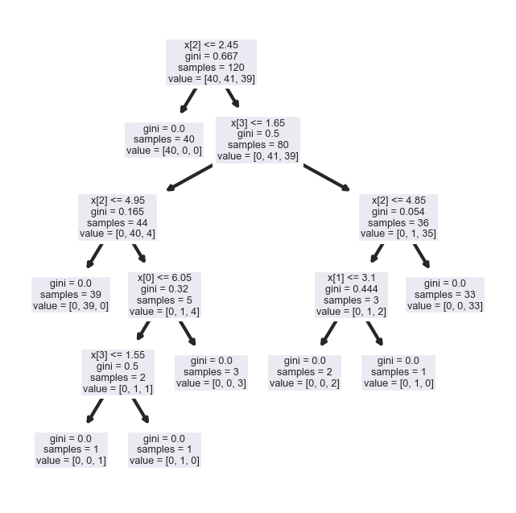

```python
from sklearn.tree import DecisionTreeClassifier, plot_tree

criterion = "gini"
max_depth = 15

# Fit decision tree classifier, no pruning
X_train, X_test, y_train, y_test = train_test_split_np(X.to_numpy(), y.to_numpy(), test_size=0.2, random_state=seed)

clf = DecisionTreeClassifier(criterion=criterion, min_samples_split=2,
    max_depth=max_depth, random_state=seed)
clf = clf.fit(X_train, y_train)

# 4.2) Predict the labels for both the training and test set, name them y_pred_train and y_pred_test.
### BEGIN SOLUTION
y_pred_test = clf.predict(X_test)
y_pred_train = clf.predict(X_train)
### END SOLUTION

test_accuracy = np.mean(y_pred_test == y_test)
train_accuracy = np.mean(y_pred_train == y_train)

print("Accuracy (Test):", test_accuracy)
print("Accuracy (Train):", train_accuracy)

# Visualize the graph. Hint: Try to maximize the figure after it displays.
fig = plt.figure(figsize=(2.5, 2.5), dpi=300)
_ = plot_tree(clf, filled=False)
print(f"Max depth of the tree: {max_depth}")
print(f"Actual depth of the tree: {clf.tree_.max_depth}")
```

**Task 4.2** Use the decision to predict the class for a new Iris observation with $\boldsymbol{x}^\ast=\begin{bmatrix}3.1 & 0.5 & 5.2 & 1.3\end{bmatrix}$. Do it by hand on pen & paper using the visualization of the tree, not the code.

*Answer*:

**Task 4.3** The decision tree has a plentitude of various controlling its operation. We perform model selection using 5 fold CV. This time we examine the effect of the `max_depth` parameter in the decision tree while fixing other parameters. Complete the code below by defining the maximum depth to explore. Save `max_depth`.

```
Stopped expandign the tree early - max tree depth: 6 vs actual depth: 5
Stopped expandign the tree early - max tree depth: 7 vs actual depth: 5
Stopped expandign the tree early - max tree depth: 8 vs actual depth: 5
Stopped expandign the tree early - max tree depth: 6 vs actual depth: 5
Stopped expandign the tree early - max tree depth: 7 vs actual depth: 5
Stopped expandign the tree early - max tree depth: 8 vs actual depth: 5
Stopped expandign the tree early - max tree depth: 6 vs actual depth: 5
Stopped expandign the tree early - max tree depth: 7 vs actual depth: 5
Stopped expandign the tree early - max tree depth: 8 vs actual depth: 5
Stopped expandign the tree early - max tree depth: 5 vs actual depth: 4
Stopped expandign the tree early - max tree depth: 6 vs actual depth: 4
Stopped expandign the tree early - max tree depth: 7 vs actual depth: 4
Stopped expandign the tree early - max tree depth: 8 vs actual depth: 4
Stopped expandign the tree early - max tree depth: 7 vs actual depth: 6
Stopped expandign the tree early - max tree depth: 8 vs actual depth: 6
```

[figure not shown]

```python
# First set the max_depth. We explore the range 1...max_depth
# ### BEGIN SOLUTION
max_depth = 8 # maybe play aorund with this
### END SOLUTION

K_folds = 5 # we do 5 fold CV here
cv_folds = kfold_np(X.shape[0], n_splits=K_folds, random_state=seed)

# Loop through the folds
errors_test = np.zeros((len(X), max_depth))
errors_train = np.zeros((len(X), max_depth))

for fold_i, data_splits in enumerate(cv_folds):
    train_index = data_splits["train_idx"]
    test_index = data_splits["test_idx"]

    X_train, X_test = X.iloc[train_index], X.iloc[test_index]
    y_train, y_test = y[train_index], y[test_index]

    for requested_depth in range(1, max_depth + 1):
        tree = DecisionTreeClassifier(criterion="gini", max_depth=requested_depth, random_state=seed,
            min_samples_split=2, min_samples_leaf=1, min_weight_fraction_leaf=0.0, max_leaf_nodes=None,
            min_impurity_decrease=0.0, ccp_alpha=0.0, splitter="best")
        tree.fit(X_train, y_train)

        y_est_test = tree.predict(X_test)
        y_est_train = tree.predict(X_train)

        errors_test[fold_i, requested_depth - 1] = np.mean(y_est_test != y_test)
        errors_train[fold_i, requested_depth - 1] = np.mean(y_est_train != y_train)

        if tree.tree_.max_depth < requested_depth:
            print(f"Stopped expandign the tree early - max tree depth: {requested_depth} vs actual depth: {tree.tree_.max_depth}")

# Plot mean errors for each depth
mean_errors_test = np.mean(errors_test, axis=0)
mean_errors_train = np.mean(errors_train, axis=0)

f = plt.figure(figsize=(5, 3))
plt.title('Leave-One-Out CV')
plt.xlabel('Maximum Tree Depth')
plt.ylabel('Classification Error (%)')
plt.plot(range(1, max_depth + 1), mean_errors_test * 100,'xb-')
plt.plot(range(1, max_depth + 1), mean_errors_train * 100,'xr-')
plt.legend(['Test Error', 'Train Error'])
plt.grid(True)
```

**Task 4.4:** Reflect on the shape of the training and test error curves. Which model complexity would you choose, and why? Why does the test error appear to plateau?

> *Hint:* Consider which depth the decision tree actually reaches during training (it may be smaller than the maximum depth you set).

*Answer:*